# Linear Time Series Models for Financial Data

#### Use the fitted model to produce 1 to 12 step ahead forecasts for the series. Include the associated standard errors for forecasts.

Not surprisingly, the forecast accuracy is poor. The log returns are noisy to begin with making the task quite difficult but, an MA 1 model also converges to the set mean quickly. This model properties are on display here. For example, the predictions quickly revert to around the mean, save for some added noise. In fact, only the $h = 1$ shows a unique value while the other estimates are essentially just the log return mean. Again, an MA 1 model has this property whereby following the first forecast horizon, the model reverts to the broad mean plus noise. This same property can be seen in the prediction standard error as well where every value is almost congruent with the series standard deviation. While the model is useful for exploring time series modelling, it doesn’t appear to have any wider predictive utility.

```r
data.frame(
  horizon = seq(1, 12, 1),
  actual = tail(crsp_dec2$log_return, 12),
  prediction = predict(crsp_eacf_arma, 12)$pred,
  return_mean = mean(crsp_dec2$log_return),
  pred_se = predict(crsp_eacf_arma, 12)$se,
  return_sd = sd(crsp_dec2$log_return)
) %>% custom_kable()
```

| horizon | actual | prediction | return_mean | pred_se | return_sd |
| --- | --- | --- | --- | --- | --- |
| 1 | 0.0356007 | 0.021896720 | 0.0081131 | 0.04755333 | 0.0477978 |
| 2 | 0.0119632 | 0.008285059 | 0.0081131 | 0.04800253 | 0.0477978 |
| 3 | 0.0636957 | 0.008285059 | 0.0081131 | 0.04800253 | 0.0477978 |
| 4 | 0.0182387 | 0.008285059 | 0.0081131 | 0.04800253 | 0.0477978 |
| 5 | 0.0376040 | 0.008285059 | 0.0081131 | 0.04800253 | 0.0477978 |
| 6 | 0.0059175 | 0.008285059 | 0.0081131 | 0.04800253 | 0.0477978 |
| 7 | 0.0309695 | 0.008285059 | 0.0081131 | 0.04800253 | 0.0477978 |
| 8 | -0.0011036 | 0.008285059 | 0.0081131 | 0.04800253 | 0.0477978 |
| 9 | -0.0144885 | 0.008285059 | 0.0081131 | 0.04800253 | 0.0477978 |
| 10 | -0.0375721 | 0.008285059 | 0.0081131 | 0.04800253 | 0.0477978 |
| 11 | -0.0611044 | 0.008285059 | 0.0081131 | 0.04800253 | 0.0477978 |
| 12 | -0.0835001 | 0.008285059 | 0.0081131 | 0.04800253 | 0.0477978 |

### Modelling Monthly Yields of Moody’s AAA bonds

Moving into the next section, I’ll be working with the Moody’s AAA bonds data. AAA bonds denote the highest credit rating Moody’s gives so these returns are from stable, trustworthy companies. Additionally, the US Treasury returns would be included here as well. Below, the summary statistics for the class show variable returns. The log return mean is well above zero indicating each month, on average, provides a positive return. The series does appear variable though given the max and min returns are quite spread. Overall though, the returns here for the AAA bonds appear good.

```r
yield_summary_stats <- yield_summary(data = bond_yields)

yield_summary_stats %>%
  custom_kable()
```

| return_type | return_min | return_median | return_mean | return_max |
| --- | --- | --- | --- | --- |
| log_yield | 0.9001613 | 1.647696 | 1.672788 | 2.740195 |
| yield | 2.4600000 | 5.195000 | 5.891158 | 15.490000 |

Density plots for each return set further reaffirm this. The log yield shows what could be three distinct time periods given it has multi-modal shape. Here, there appears to be a lower, medium, and high yield time periods.

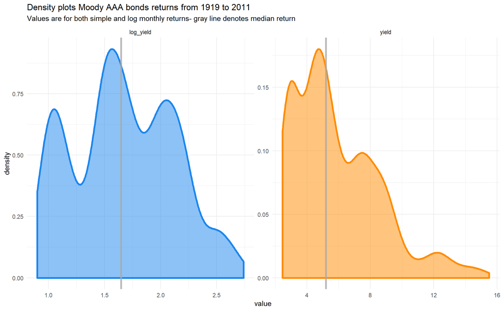

```r
bond_yields %>%
  select(-date) %>%
  gather(key = "return_type", value = "value") %>%
  ggplot(aes(value, colour = return_type, fill = return_type)) +
  geom_density(size = 1.3, show.legend = F, alpha = .5) +
  geom_vline(data = yield_summary_stats,
             aes(xintercept = return_median),
             alpha = .8, size = 1.3 ,colour = "darkgray") +
  facet_wrap(facets = "return_type", scales = "free") +
  scale_colour_manual(values = colours) +
  scale_fill_manual(values = colours) +
  labs(title = "Density plots Moody AAA bonds returns from 1919 to 2011",
       subtitle = "Values are for both simple and log monthly returns- gray line denotes median return")
```

The series for each variable shows declining yields from 1920 into WWII but, a steady increase in the post ward era into a high point in the 1980s. Beyond this, yields for these AAA bonds have decreased to levels below initial values in the 1920s. Given these observations, the series appears to be non-stationary given the log yield is dependent on time. Here, the mean and variance is not uniform across the series, which makes the yield forecast time dependent. Additionally, the log yield series shows clear signs of auto-correlation.

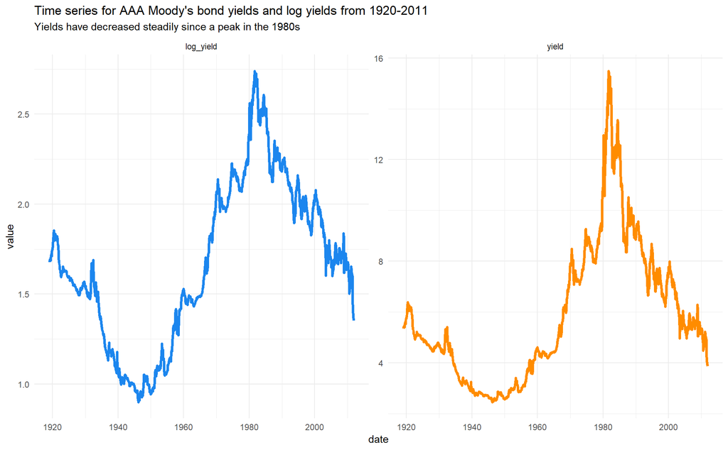

```r
bond_yields %>%
  gather(key = "yield_type", value = "value", -date) %>%
  ggplot(aes(date, value, colour = yield_type)) +
  geom_line(size = 1.3, show.legend = F) +
  facet_wrap(facets = "yield_type", scales = "free") +
  scale_colour_manual(values = colours) +
  labs(title = "Time series for AAA Moody's bond yields and log yields from 1920-2011",
       subtitle = "Yields have decreased steadily since a peak in the 1980s")
```

#### Fit an appropriate time series model using log yield

With the initial exploratory work done, I’ve switched to look at the time series properties of the log yields. The initial step is checking stationarity using an Augmented Dickey–Fuller Test. With a very high p-value, the null hypothesis, which is that the data is non-stationary, cannot be rejected. As such, the serial auto-correlation in the set is confirmed. This means that a full ARIMA (p, d, q) model is likely necessary.

```r
adf.test(x = bond_yields$log_yield)
```

```
##
##  Augmented Dickey-Fuller Test
##
## data:  bond_yields$log_yield
## Dickey-Fuller = -0.91019, Lag order = 10, p-value = 0.9518
## alternative hypothesis: stationary
```

Following this up, I’ve developed an ACF here. It shows both serial auto-correlation and long-memory residuals as well. This suggests that any modelling work will need a fractional differencing term.

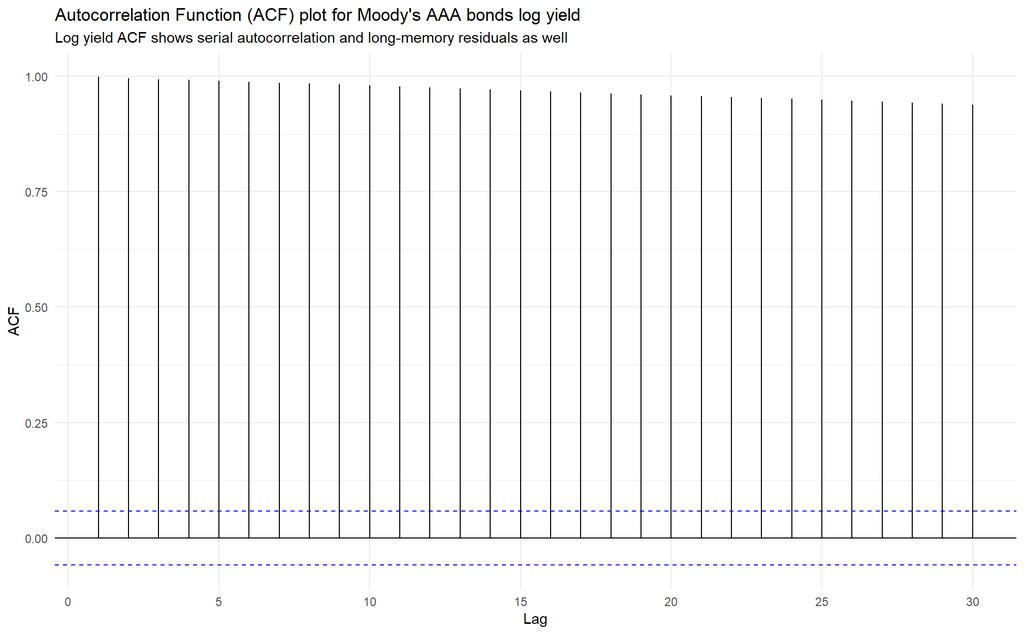

```r
ggAcf(x = bond_yields$log_yield) +
  labs(title = "Autocorrelation Function (ACF) plot for Moody's AAA bonds log yield",
       subtitle = "Log yield ACF shows serial autocorrelation and long-memory residuals as well")
```

To get a better sense of the auto-correlation without the long memory, I’ve differenced the log yields. This approach shows one significant spike at lag 1 but, no other lags. This suggests using a p = 1 model might make sense for the AR component.

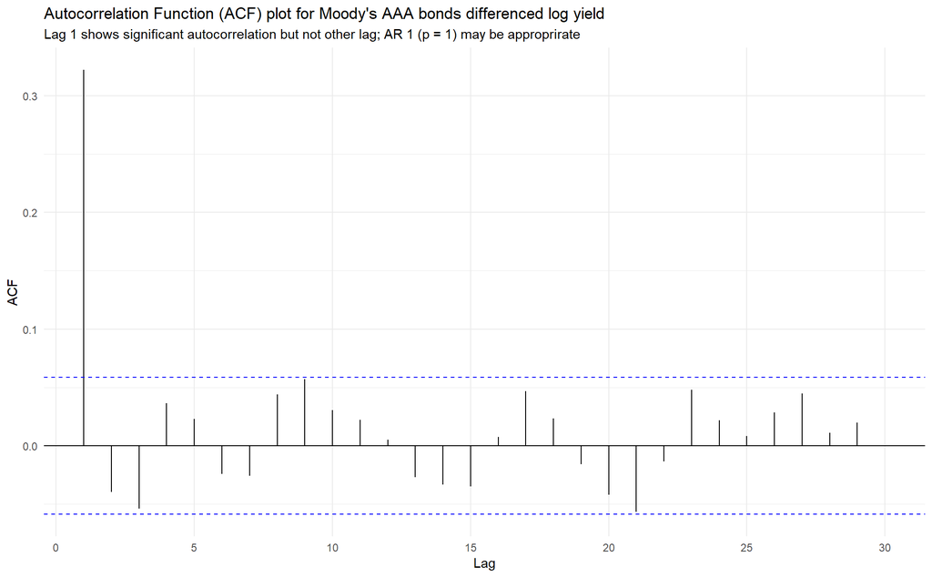

```r
ggAcf(x = diff(bond_yields$log_yield)) +
  labs(title = "Autocorrelation Function (ACF) plot for Moody's AAA bonds differenced log yield",
       subtitle = "Lag 1 shows significant autocorrelation but not other lag; AR 1 (p = 1) may be approprirate")
```

I’ve also included a PACF plot to better understand the possible MA term. It’s clear that lag 3 shows the last significant spike and therefore, this is a good starting point for the model.

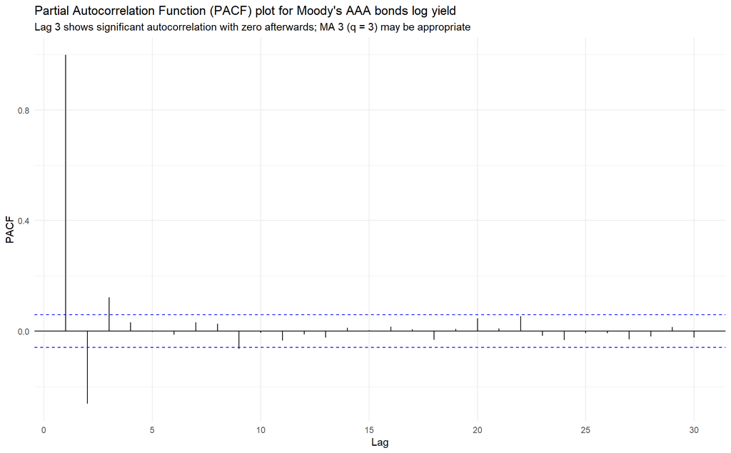

```r
ggPacf(x = bond_yields$log_yield) +
  labs(title = "Partial Autocorrelation Function (PACF) plot for Moody's AAA bonds log yield",
       subtitle = "Lag 3 shows significant autocorrelation with zero afterwards; MA 3 (q = 3) may be appropriate")
```

Given the previous work, I’ve fitted a fractional difference ARIMA, or ARFIMA, model. All the model coefficients are significant.

```r
log_yield_arfima <- fracdiff(x = head(bond_yields$log_yield, nrow(bond_yields) - 12),
                             nar = 1, nma = 3, h = .00001)

summary(log_yield_arfima)
```

```
##
## Call:
##   fracdiff(x = head(bond_yields$log_yield, nrow(bond_yields) -      12), nar = 1, nma = 3, h = 1e-05)
##
## Coefficients:
##      Estimate Std. Error  z value Pr(>|z|)
## d    0.093475   0.006900   13.547  < 2e-16 ***
## ar   0.997067   0.020125   49.543  < 2e-16 ***
## ma1 -0.278306   0.002308 -120.577  < 2e-16 ***
## ma2  0.104312   0.017346    6.014 1.82e-09 ***
## ma3  0.126941   0.017022    7.457 8.83e-14 ***
## ---
## Signif. codes:  0 '***' 0.001 '**' 0.01 '*' 0.05 '.' 0.1 ' ' 1
## sigma[eps] = 0.02120354
## [d.tol = 0.0001221, M = 100, h = 1e-05]
## Log likelihood:  2683 ==> AIC = -5353.994 [6 deg.freedom]
```

For comparison, I’ve created an ARIMA(1, 1, 3) here to assess. However, the coefficients do not appear significant. Only MA 3 appears to have a low enough z-value to show significance.

```r
Arima(y = head(bond_yields$log_yield, nrow(bond_yields) - 12), order = c(1, 1, 3))
```

```
## Series: head(bond_yields$log_yield, nrow(bond_yields) - 12)
## ARIMA(1,1,3)
##
## Coefficients:
##           ar1     ma1     ma2      ma3
##       -0.1006  0.4720  0.0102  -0.0910
## s.e.   0.2929  0.2911  0.1119   0.0292
##
## sigma^2 estimated as 0.0004513:  log likelihood=2680.37
## AIC=-5350.74   AICc=-5350.69   BIC=-5325.72
```

```r
(log_yield_arima <- Arima(y = head(bond_yields$log_yield, nrow(bond_yields) - 12),
                         order = c(0, 1, 3)))
```

```
## Series: head(bond_yields$log_yield, nrow(bond_yields) - 12)
## ARIMA(0,1,3)
##
## Coefficients:
##          ma1      ma2      ma3
##       0.3726  -0.0259  -0.0916
## s.e.  0.0300   0.0314   0.0289
##
## sigma^2 estimated as 0.000451:  log likelihood=2680.28
## AIC=-5352.56   AICc=-5352.53   BIC=-5332.55
```

The model residuals for both the ARIMA and ARFIMA. Both appear to resemble white noise and there are no ACF spikes past the significance lines. This signals that both sets of residuals do not have any identifiable pattern and are stationary.

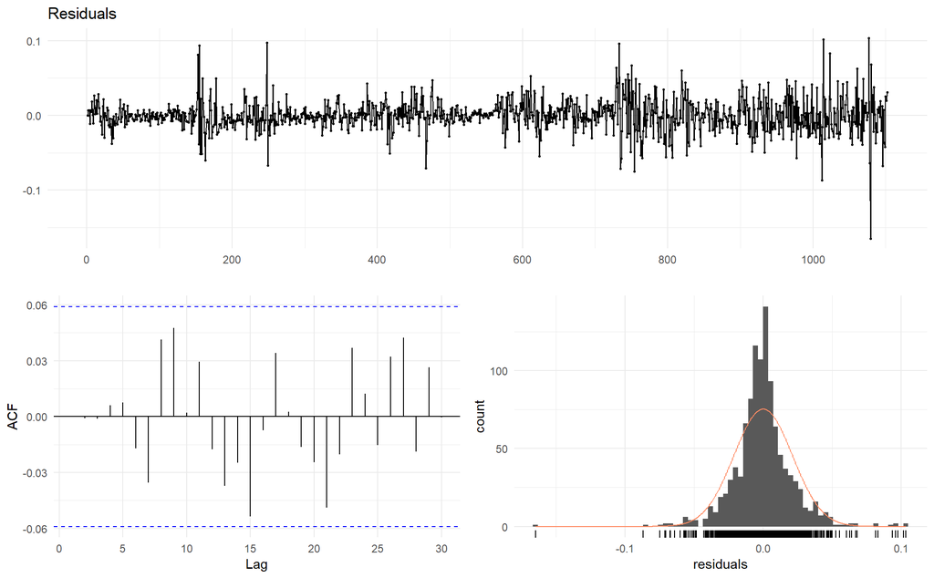

```r
checkresiduals(log_yield_arfima, lag = 28)
```

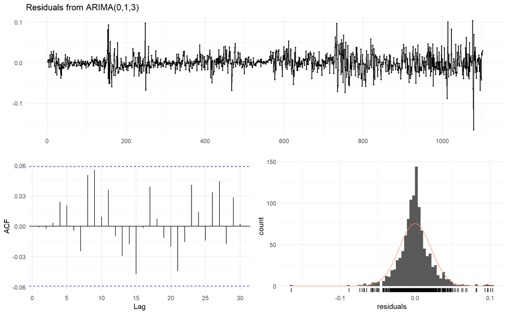

```
##
##  Ljung-Box test
##
## data:  Residuals from ARIMA(0,1,3)
## Q* = 24.669, df = 25, p-value = 0.4811
##
## Model df: 3.   Total lags used: 28
```

```r
checkresiduals(log_yield_arima, lag = 28)
```

```r
log_yield_predictions <- data.frame(
  horizon = seq(1, 12, 1),
  actual = tail(bond_yields$log_yield, 12),
  arima_pred = predict(log_yield_arima, 12)$pred,
  arfima_pred = predict(log_yield_arfima, 12)$mean,
  series_mean = mean(bond_yields$log_yield)
)

log_yield_predictions %>%
  custom_kable()
```

| horizon | actual | arima_pred | arfima_pred | series_mean |
| --- | --- | --- | --- | --- |
| 1 | 1.613430 | 1.591345 | 1.589425 | 1.672788 |
| 2 | 1.617406 | 1.588838 | 1.585026 | 1.672788 |
| 3 | 1.652497 | 1.586139 | 1.581135 | 1.672788 |
| 4 | 1.635106 | 1.586139 | 1.580737 | 1.672788 |
| 5 | 1.640937 | 1.586139 | 1.580420 | 1.672788 |
| 6 | 1.601406 | 1.586139 | 1.580110 | 1.672788 |
| 7 | 1.607436 | 1.586139 | 1.579804 | 1.672788 |
| 8 | 1.595339 | 1.586139 | 1.579502 | 1.672788 |
| 9 | 1.474763 | 1.586139 | 1.579208 | 1.672788 |
| 10 | 1.408545 | 1.586139 | 1.578925 | 1.672788 |
| 11 | 1.381282 | 1.586139 | 1.578653 | 1.672788 |
| 12 | 1.353255 | 1.586139 | 1.578394 | 1.672788 |

```r
mean_abs_error <- function(actual, pred){
  errors <- (pred %>% as.numeric() - actual)
  abs_errors <- abs(errors)
  mae <- mean(abs_errors) %>% round(4)
}

data.frame(
  model = c("ARIMA", "ARFIMA"),
  MAE = c(
    mean_abs_error(actual = log_yield_predictions$actual,
                   pred = log_yield_predictions$arima_pred),
    mean_abs_error(actual = log_yield_predictions$actual,
                   pred = log_yield_predictions$arfima_pred)
  )
) %>% custom_kable()
```

| model | MAE |
| --- | --- |
| ARIMA | 0.0828 |
| ARFIMA | 0.0837 |